# Effects of Loan and Borrower Features on Loan Status Outcome

## Investigation Overview

In this investigation, I wanted to look at the Features of Loan and Borrower that could be used to predict the Loan Status Outcome (i.e. whether loan is performing or non-performing).

## Dataset Overview

```python
# import all packages and set plots to be embedded inline
import numpy as np
import pandas as pd
import matplotlib.pyplot as plt
import seaborn as sb

%matplotlib inline

# suppress warnings from final output
import warnings
warnings.simplefilter("ignore")
```

```python
# load in the dataset into a pandas dataframe
df = pd.read_csv('prosperLoanData.csv')
```

```python
df_clean = df.copy()
```

```python
#extract only identified features

cols = ["LoanStatus", "Term", "BorrowerAPR", "LoanOriginalAmount", "MonthlyLoanPayment", "ListingCategory (numeric)",
        "ProsperScore", "EmploymentStatus", "EmploymentStatusDuration", "IsBorrowerHomeowner", "CurrentCreditLines",
        "AvailableBankcardCredit", "DebtToIncomeRatio", "StatedMonthlyIncome"]

df_clean = df_clean[cols]
```

```python
# data wrangling, removing diamonds with inconsistent or missing data.
df_clean.dropna(axis=0, subset=['BorrowerAPR','CurrentCreditLines','EmploymentStatusDuration', "DebtToIncomeRatio", "ProsperScore"])
```

|  | LoanStatus | Term | BorrowerAPR | LoanOriginalAmount | MonthlyLoanPayment | ListingCategory (numeric) | ProsperScore | EmploymentStatus | EmploymentStatusDuration | IsBorrowerHomeowner | CurrentCreditLines | AvailableBankcardCredit | DebtToIncomeRatio | StatedMonthlyIncome |
| --- | --- | --- | --- | --- | --- | --- | --- | --- | --- | --- | --- | --- | --- | --- |
| 1 | Current | 36 | 0.12016 | 10000 | 318.93 | 2 | 7.0 | Employed | 44.0 | False | 14.0 | 10266.0 | 0.18 | 6125.000000 |
| 3 | Current | 36 | 0.12528 | 10000 | 321.45 | 16 | 9.0 | Employed | 113.0 | True | 5.0 | 30754.0 | 0.15 | 2875.000000 |
| 4 | Current | 36 | 0.24614 | 15000 | 563.97 | 2 | 4.0 | Employed | 44.0 | True | 19.0 | 695.0 | 0.26 | 9583.333333 |
| 5 | Current | 60 | 0.15425 | 15000 | 342.37 | 1 | 10.0 | Employed | 82.0 | True | 21.0 | 86509.0 | 0.36 | 8333.333333 |
| 6 | Current | 36 | 0.31032 | 3000 | 122.67 | 1 | 2.0 | Employed | 172.0 | False | 10.0 | 1929.0 | 0.27 | 2083.333333 |
| 7 | Current | 36 | 0.23939 | 10000 | 372.60 | 2 | 4.0 | Employed | 103.0 | False | 6.0 | 2181.0 | 0.24 | 3355.750000 |
| 8 | Current | 36 | 0.07620 | 10000 | 305.54 | 7 | 9.0 | Employed | 269.0 | True | 17.0 | 77696.0 | 0.25 | 3333.333333 |
| 9 | Current | 36 | 0.07620 | 10000 | 305.54 | 7 | 11.0 | Employed | 269.0 | True | 17.0 | 77696.0 | 0.25 | 3333.333333 |
| 10 | Current | 60 | 0.27462 | 13500 | 395.37 | 1 | 7.0 | Employed | 300.0 | False | 2.0 | 363.0 | 0.12 | 7500.000000 |
| 12 | Past Due (1-15 days) | 36 | 0.17969 | 4000 | 137.39 | 1 | 4.0 | Employed | 1.0 | False | 9.0 | 3626.0 | 0.18 | 2416.666667 |
| 13 | Current | 36 | 0.13138 | 8500 | 275.63 | 1 | 8.0 | Employed | 98.0 | True | 9.0 | 19129.0 | 0.09 | 5833.333333 |
| 14 | Current | 60 | 0.11695 | 19330 | 415.37 | 1 | 8.0 | Employed | 35.0 | False | 25.0 | 42204.0 | 0.20 | 10833.333333 |
| 15 | Defaulted | 36 | 0.35797 | 4000 | 173.71 | 13 | 5.0 | Other | 121.0 | True | 10.0 | 178.0 | 0.49 | 5500.000000 |
| 16 | Current | 60 | 0.30748 | 4000 | 124.76 | 6 | 4.0 | Full-time | 133.0 | True | 6.0 | 27.0 | 0.15 | 8291.666667 |
| 18 | Current | 36 | 0.12528 | 15000 | 482.18 | 1 | 7.0 | Employed | 179.0 | False | 10.0 | 15507.0 | 0.24 | 6250.000000 |
| 19 | Current | 60 | 0.24754 | 6500 | 180.45 | 1 | 8.0 | Employed | 18.0 | False | 15.0 | 1987.0 | 0.41 | 3075.000000 |
| 20 | Current | 36 | 0.16732 | 14000 | 472.66 | 1 | 7.0 | Employed | 175.0 | True | 9.0 | 822.0 | 0.20 | 5166.666667 |
| 22 | Current | 36 | 0.35356 | 4000 | 172.76 | 1 | 2.0 | Other | 68.0 | False | 9.0 | 4465.0 | 9.20 | 118.333333 |
| 23 | Defaulted | 36 | 0.28032 | 2000 | 78.67 | 15 | 5.0 | Employed | 3.0 | False | 7.0 | 607.0 | 0.39 | 2500.000000 |
| 24 | Current | 36 | 0.19859 | 4000 | 141.02 | 1 | 5.0 | Employed | 91.0 | True | 10.0 | 4770.0 | 0.16 | 2333.333333 |
| 25 | Current | 36 | 0.30182 | 4000 | 161.78 | 15 | 3.0 | Employed | 15.0 | False | 2.0 | 4069.0 | 0.12 | 6974.000000 |
| 26 | Completed | 60 | 0.30748 | 4000 | 124.76 | 1 | 3.0 | Employed | 25.0 | False | 7.0 | 3619.0 | 0.11 | 3885.916667 |
| 27 | Completed | 36 | 0.11296 | 4000 | 0.00 | 1 | 9.0 | Full-time | 10.0 | True | 16.0 | 30794.0 | 0.26 | 6666.666667 |
| 28 | Current | 36 | 0.20268 | 10000 | 354.54 | 2 | 4.0 | Employed | 48.0 | True | 5.0 | 6381.0 | 0.12 | 3600.000000 |
| 29 | Current | 36 | 0.15223 | 35000 | 1169.03 | 1 | 6.0 | Employed | 16.0 | True | 24.0 | 24401.0 | 0.32 | 10416.666667 |
| 30 | Completed | 36 | 0.12782 | 10000 | 322.62 | 20 | 9.0 | Employed | 44.0 | False | 4.0 | 25779.0 | 0.11 | 3750.000000 |
| 31 | Current | 36 | 0.35797 | 2000 | 86.85 | 2 | 5.0 | Other | 44.0 | False | 0.0 | 0.0 | 0.04 | 2250.000000 |
| 32 | Current | 36 | 0.16324 | 25000 | 839.22 | 1 | 8.0 | Employed | 269.0 | True | 9.0 | 5049.0 | 0.22 | 7000.000000 |
| 33 | Completed | 36 | 0.08191 | 16000 | 500.28 | 7 | 10.0 | Employed | 7.0 | False | 6.0 | 3859.0 | 0.05 | 13083.333333 |
| 34 | Current | 36 | 0.22966 | 10000 | 367.57 | 1 | 5.0 | Other | 426.0 | True | 6.0 | 266.0 | 0.17 | 4058.333333 |
| ... | ... | ... | ... | ... | ... | ... | ... | ... | ... | ... | ... | ... | ... | ... |
| 113887 | Current | 60 | 0.21156 | 6500 | 167.69 | 1 | 3.0 | Employed | 480.0 | True | 20.0 | 14513.0 | 0.16 | 12500.000000 |
| 113888 | Current | 36 | 0.14853 | 3000 | 99.63 | 7 | 5.0 | Employed | 13.0 | False | 3.0 | 6295.0 | 0.20 | 1000.000000 |
| 113889 | Chargedoff | 12 | 0.17969 | 4000 | 355.84 | 13 | 8.0 | Employed | 8.0 | False | 13.0 | 7442.0 | 0.17 | 8333.333333 |
| 113892 | Current | 36 | 0.15223 | 8000 | 267.21 | 7 | 7.0 | Employed | 162.0 | False | 10.0 | 218.0 | 0.12 | 10000.000000 |
| 113895 | Current | 60 | 0.20398 | 14000 | 355.51 | 2 | 7.0 | Employed | 13.0 | True | 22.0 | 40979.0 | 0.23 | 7500.000000 |
| 113898 | Completed | 36 | 0.16005 | 4500 | 153.47 | 5 | 8.0 | Part-time | 37.0 | False | 8.0 | 5062.0 | 0.15 | 1539.166667 |
| 113900 | Current | 36 | 0.16678 | 10000 | 337.18 | 1 | 6.0 | Employed | 108.0 | False | 19.0 | 28823.0 | 0.42 | 3466.666667 |
| 113901 | Current | 60 | 0.15016 | 20000 | 452.40 | 1 | 8.0 | Employed | 86.0 | True | 15.0 | 5125.0 | 0.30 | 6000.000000 |
| 113905 | Chargedoff | 36 | 0.35797 | 4000 | 173.71 | 1 | 2.0 | Employed | 175.0 | True | 17.0 | 2868.0 | 0.35 | 3250.000000 |
| 113907 | Current | 36 | 0.35356 | 4000 | 172.76 | 1 | 2.0 | Employed | 86.0 | False | 15.0 | 3784.0 | 0.40 | 2166.666667 |
| 113909 | Current | 60 | 0.27554 | 6000 | 176.04 | 2 | 7.0 | Employed | 265.0 | True | 6.0 | 9523.0 | 0.24 | 3333.333333 |
| 113910 | Current | 36 | 0.32446 | 4000 | 166.54 | 1 | 2.0 | Employed | 8.0 | False | 9.0 | 321.0 | 0.18 | 18756.000000 |
| 113911 | Current | 36 | 0.25330 | 10000 | 379.58 | 14 | 3.0 | Employed | 51.0 | False | 7.0 | 4316.0 | 0.29 | 3333.333333 |
| 113912 | Current | 36 | 0.06726 | 4000 | 121.78 | 2 | 11.0 | Employed | 102.0 | False | 10.0 | 50669.0 | 0.20 | 2500.000000 |
| 113913 | Completed | 36 | 0.12410 | 8000 | 259.27 | 1 | 9.0 | Full-time | 19.0 | True | 19.0 | 24505.0 | 0.25 | 9750.000000 |
| 113916 | Current | 36 | 0.33286 | 4000 | 168.32 | 13 | 6.0 | Employed | 149.0 | False | 5.0 | 67.0 | 0.15 | 4583.333333 |
| 113917 | Current | 36 | 0.32446 | 4000 | 166.54 | 1 | 2.0 | Employed | 32.0 | False | 8.0 | 2248.0 | 0.40 | 1916.666667 |
| 113919 | Current | 36 | 0.27285 | 4000 | 155.80 | 2 | 3.0 | Other | 12.0 | True | 8.0 | 6755.0 | 0.22 | 2500.000000 |
| 113920 | Current | 36 | 0.35356 | 4000 | 172.76 | 1 | 2.0 | Employed | 110.0 | True | 15.0 | 11766.0 | 0.25 | 5208.333333 |
| 113924 | Current | 60 | 0.17317 | 5000 | 118.92 | 13 | 8.0 | Employed | 56.0 | False | 6.0 | 5165.0 | 0.17 | 3208.333333 |
| 113925 | Current | 36 | 0.31032 | 4000 | 163.56 | 1 | 2.0 | Employed | 31.0 | False | 7.0 | 2489.0 | 0.28 | 2333.333333 |
| 113928 | Completed | 36 | 0.22362 | 2000 | 73.30 | 3 | 6.0 | Full-time | 22.0 | False | 4.0 | 3746.0 | 0.27 | 2333.333333 |
| 113929 | Completed | 36 | 0.30285 | 2500 | 101.25 | 2 | 3.0 | Employed | 25.0 | False | 7.0 | 7537.0 | 0.05 | 4333.333333 |
| 113930 | Current | 36 | 0.20053 | 3000 | 106.05 | 1 | 6.0 | Employed | 85.0 | True | 16.0 | 1322.0 | 0.20 | 6250.000000 |
| 113931 | Current | 60 | 0.15016 | 25000 | 565.50 | 3 | 6.0 | Employed | 12.0 | False | 13.0 | 12056.0 | 0.28 | 8146.666667 |
| 113932 | Current | 36 | 0.22354 | 10000 | 364.74 | 1 | 5.0 | Employed | 246.0 | True | 9.0 | 1886.0 | 0.13 | 4333.333333 |
| 113933 | FinalPaymentInProgress | 36 | 0.13220 | 2000 | 65.57 | 7 | 8.0 | Employed | 21.0 | True | 14.0 | 6658.0 | 0.11 | 8041.666667 |
| 113934 | Current | 60 | 0.23984 | 10000 | 273.35 | 1 | 3.0 | Employed | 84.0 | True | 12.0 | 7853.0 | 0.51 | 2875.000000 |
| 113935 | Completed | 60 | 0.28408 | 15000 | 449.55 | 2 | 5.0 | Full-time | 94.0 | True | 11.0 | 4137.0 | 0.48 | 3875.000000 |
| 113936 | Current | 36 | 0.13189 | 2000 | 64.90 | 1 | 7.0 | Employed | 244.0 | False | 10.0 | 675.0 | 0.23 | 4583.333333 |

77543 rows × 14 columns

## Distribution of Loan Status Outcome

Loan Status in the dataset take on two main categories: Performing Loans and Non-Performing Loans.

IMF's definition of Non-Performing loans are as follows:

1. Payments of interest and principal are past due by 90 days or more
2. At least 90 days of interest payments have been capitalized, refinanced or delayed by agreement
3. Payments are less than 90 days overdue, but there are other good reasons to doubt that payments will be made in full".

For ease of analysis, the Non-Performing Loans includes loans that are Charged Off, Defaulted, and Past Due (> 1 day). The Performing Loans include loans that are Completed, Current, and FinalPaymentInProgress.

```python
df_clean["LoanStatusCat"] = df_clean.LoanStatus
```

```python
cleanup_nums = {"LoanStatusCat": {"Cancelled": "performing", "Completed":
                                  "performing", "Current": "performing",
                               "FinalPaymentInProgress": "performing",
                                  "Chargedoff": "nonperforming",
                               "Defaulted": "nonperforming",
                                  "Past Due (1-15 days)": "nonperforming",
                               "Past Due (16-30 days)": "nonperforming",
                                  "Past Due (31-60 days)": "nonperforming",
                               "Past Due (61-90 days)": "nonperforming",
                               "Past Due (91-120 days)": "nonperforming",
                               "Past Due (>120 days)": "nonperforming"}}
```

```python
df_clean.replace(cleanup_nums, inplace = True)
```

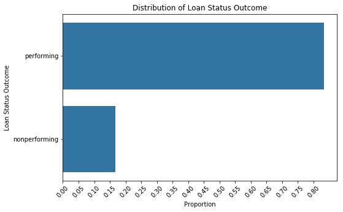

```python
# create plot with relative frequency for estimate of proportions
n_points = df_clean.shape[0]
max_count = df_clean['LoanStatusCat'].value_counts().max()
max_prop = max_count / n_points

# generate tick mark locations and names
tick_props = np.arange(0, max_prop, 0.05)
tick_names = ['{:0.2f}'.format(v) for v in tick_props]

# create the plot
plt.figure(figsize = [8,5])
plt.title('Distribution of Loan Status Outcome')
base_color = sb.color_palette()[0]
sb.countplot(data = df_clean, y= 'LoanStatusCat', color = base_color)
plt.xticks(tick_props * n_points, tick_names, rotation = 45)
plt.xlabel('Proportion')
plt.ylabel('Loan Status Outcome');
```

## Feature of Loan

There are many features of a loan. The Monthly Loan Payment is a key feature.

## Distribution of Monthly Loan Payment

Monthly Loan Payment refers to the dollar amount of loan payment per month. The amount is typically less than \$1000.

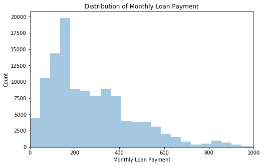

```python
plt.figure(figsize=[8, 5])
sb.distplot(df_clean.MonthlyLoanPayment, kde = False);
plt.title('Distribution of Monthly Loan Payment')
plt.xlim([0,1000])
plt.ylabel('Count')
plt.xlabel('Monthly Loan Payment')
plt.show()
```

## Features of Borrower

Features of Borrower can be classified into five main categories, each with one key variable:

1. Earnings-related Features: Monthly Income
2. Debt-related Features: Debt-To-Income Ratio
3. Credit-related Features: Available Bankcard Credit
4. Asset-related Features: Homeownership
5. Aggregated Features: Prosper Score

## Distribution of Earnings-related Feature

Monthly Income refers to the borrower's income per month. The hypothesis is that with higher income, the borrower has more financial resources. This leads to lower likelihood of Non-Performing Loans.

After removing outliers, monthly income is typically less than \$15,000.

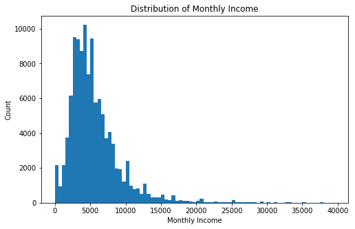

```python
plt.figure(figsize=[8, 5])
df_clean = df_clean[df_clean.StatedMonthlyIncome<=40000]
bins = np.arange(0, 40000, 500)
plt.hist(data = df_clean, x = 'StatedMonthlyIncome', bins=bins)
plt.title('Distribution of Monthly Income')
plt.ylabel('Count')
plt.xlabel('Monthly Income')
plt.show();
```

## Distribution of Debt-related Feature

Debt-To-Income Ratio refers to that of the borrower. A value less than 1 indicates that the borrower's income is sufficient to pay off all debt. In the histogram below, the value is typically less than 1. But this is after removing outliers with ratio as high as 10.

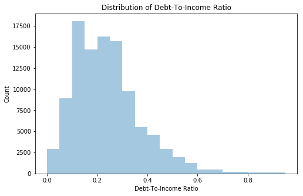

```python
#investigating further on an even smaller bin size & removing outliers
df_clean = df_clean[df_clean.DebtToIncomeRatio<=1]

plt.figure(figsize=[8, 5])
bins = np.arange(0, 1, 0.05)
sb.distplot(df_clean.DebtToIncomeRatio, kde = False, bins = bins);

plt.title('Distribution of Debt-To-Income Ratio')
plt.ylabel('Count')
plt.xlabel('Debt-To-Income Ratio')
plt.show();
```

## Distribution of Credit-related Feature

Available Bankcard Credit refers to the total available credit via bank card. The amount is related to the credit score and income of the borrower.

The first histogram shows a distribution with a long tail. This indicates a log-normal distribution. In the second histogram, Available Bankcard Credit is plotted on a logarithmic scale to show the Gaussian distribution.

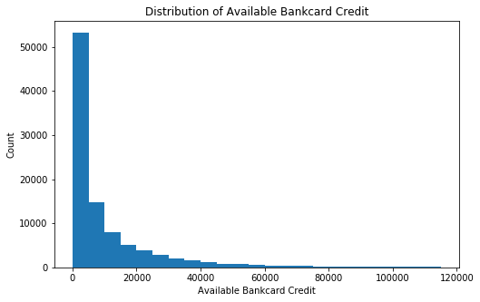

```python
# remove loans with AvailableBankcardCredit greater than 120k, which are outliers
df_clean = df_clean[df_clean.AvailableBankcardCredit<=120000]

# Distribution of AvailableBankcardCredit by removing outliers
plt.figure(figsize=[8, 5])
bins_range = np.arange(0, 120000, 5000)
plt.hist(data = df_clean, x = 'AvailableBankcardCredit', bins=bins_range);
#insert labels

plt.title('Distribution of Available Bankcard Credit')
plt.ylabel('Count')
plt.xlabel('Available Bankcard Credit')
plt.show();
```

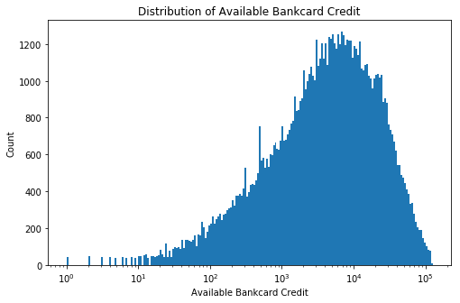

```python
# there's a long tail in the distribution, so let's put it on a log scale instead
log_binsize = 0.025
bins = 10 ** np.arange(0, np.log10(df_clean.AvailableBankcardCredit.max())+log_binsize, log_binsize)

plt.figure(figsize=[8, 5])
plt.hist(data = df_clean, x = df_clean.AvailableBankcardCredit, bins = bins)
plt.xscale('log')
plt.xlabel('Available Bankcard Credit')
plt.title('Distribution of Available Bankcard Credit')
plt.ylabel('Count')
plt.show();
```

## Distribution of Asset-related Feature

Homeownership is a categorical variable referring to whether the borrower has a mortgage or a home under their name. The hypothesis is that with homeownership, the borrower can use the house as collateral, and will have lower Borrower APR, hence, lower likelihood of Non-Performing Loans.

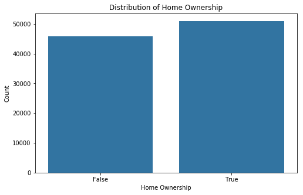

```python
plt.figure(figsize=[8, 5])

base_color = sb.color_palette()[0]
sb.countplot(data=df_clean,x="IsBorrowerHomeowner",color= base_color)

plt.xlabel('Home Ownership')
plt.title('Distribution of Home Ownership')
plt.ylabel('Count')
plt.show();
```

## Distribution of Aggregated Feature

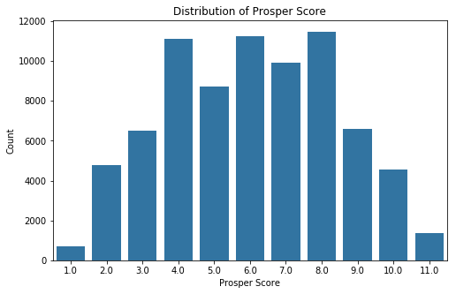

```python
plt.figure(figsize=[8, 5])

base_color = sb.color_palette()[0]
sb.countplot(data=df_clean,x="ProsperScore",color= base_color)

plt.xlabel('Prosper Score')
plt.title('Distribution of Prosper Score')
plt.ylabel('Count')
plt.show();
```

## Loan Status Outcome by Feature of Loan and Features of Borrower (Earning-related)

The Loan Status Outcome is affected by the Features of Loan and Borrower.

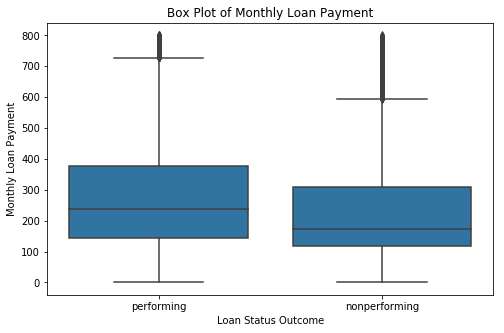

```python
# remove loans with AvailableBankcardCredit greater than 120k, which are outliers
df_clean = df_clean[df_clean.MonthlyLoanPayment<=800]

# plotting
plt.figure(figsize=[8, 5])
sb.boxplot(data = df_clean, x = 'LoanStatusCat', y = 'MonthlyLoanPayment', color = sb.color_palette()[0])

plt.xlabel('Loan Status Outcome')
plt.title('Box Plot of Monthly Loan Payment')
plt.ylabel('Monthly Loan Payment')
plt.show();
```

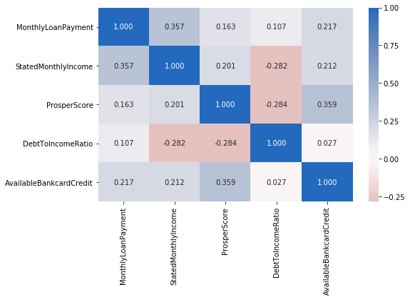

```python
numeric_vars = ['MonthlyLoanPayment', 'StatedMonthlyIncome', 'ProsperScore', 'DebtToIncomeRatio', 'AvailableBankcardCredit']

# pairwise correlation plot of numerical variables
plt.figure(figsize = [8, 5])
sb.heatmap(df_clean[numeric_vars].corr(), annot = True, fmt = '.3f',
           cmap = 'vlag_r', center = 0)
plt.show();
```

## Loan Status Outcome by Features of Borrower (Debt-related)

The hypothesis is that Non-Performing Loans will have higher Debt-to-Income Ratio. The effect of Debt-related feature on Loan Status is not very obvious. But closely looking at the top of the violin plot, one can see larger area for Non-Performing Loans in the higher DE ratio region (DE ratio > 0.4).

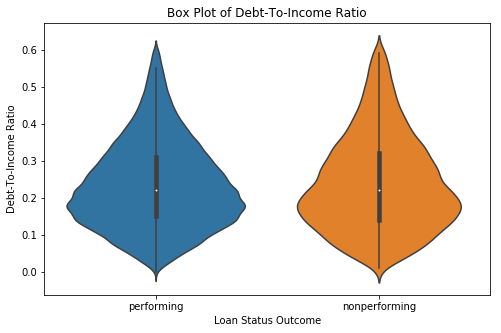

```python
# remove loans with AvailableBankcardCredit greater than 120k, which are outliers
df_clean = df_clean[df_clean.DebtToIncomeRatio<=0.6]

# plotting
plt.figure(figsize=[8, 5])
sb.violinplot(data = df_clean, x = 'LoanStatusCat', y = 'DebtToIncomeRatio')

plt.xlabel('Loan Status Outcome')
plt.title('Box Plot of Debt-To-Income Ratio')
plt.ylabel('Debt-To-Income Ratio')
plt.show();
```

## Loan Status Outcome by Features of Borrower (Credit-related)

The boxplot suggests that higher Available Bankcard Credit corresponds to lower likelihood of Non-Rerforming Loans. Performing Loans has higher means and 25th/75th-percentiles than Non-Performing Loans. This makes sense because Credit-related features are correlated with the Credit Score, which is a measure of the likelihood of a credit card default, a proxy for Non-Rerforming Loans.

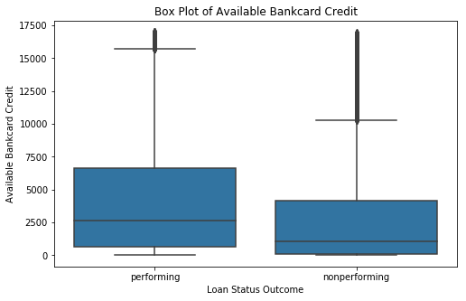

```python
# remove loans with AvailableBankcardCredit greater than 120k, which are outliers
df_clean = df_clean[df_clean.AvailableBankcardCredit<=17000]

# plotting
plt.figure(figsize=[8, 5])
sb.boxplot(data = df_clean, x = 'LoanStatusCat', y = 'AvailableBankcardCredit', color = sb.color_palette()[0])

plt.xlabel('Loan Status Outcome')
plt.title('Box Plot of Available Bankcard Credit')
plt.ylabel('Available Bankcard Credit')
plt.show();
```

## Loan Status Outcome by Features of Borrower (Asset-related)

The effect of homeownership on Loan Status Outcome is not obvious in the clustered bar chart, even though one can notice lower levels of homeownership for Non-Performing Loans.

Further investigation using the point plots show that homeownership have an effect on the loan's Monthly Payment, and Available Bankcard Credit. Since Monthly Payment and Available Bankcard Credit were shown above to have an positive effect on Loan Status, it strengthens the hypothesis that homeownership corresponds to lower likelihood of Non-Performing Loans

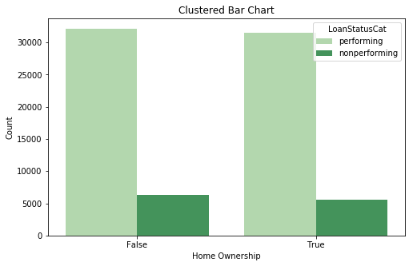

```python
# Clustered Bar Chart
plt.figure(figsize=[8, 5])
sb.countplot(data = df_clean, x = 'IsBorrowerHomeowner', hue = 'LoanStatusCat', palette = 'Greens')

plt.xlabel('Home Ownership')
plt.title('Clustered Bar Chart')
plt.ylabel('Count')
plt.show();
```

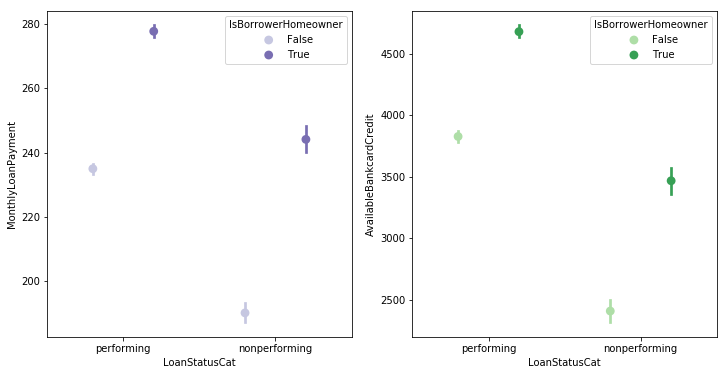

```python
fig, ax = plt.subplots(ncols=2, figsize=[12,6])
sb.pointplot(data = df_clean, x = 'LoanStatusCat', y = 'MonthlyLoanPayment', hue = 'IsBorrowerHomeowner',
           palette = 'Purples', linestyles = '', dodge = 0.4, ax=ax[0])
sb.pointplot(data = df_clean, x = 'LoanStatusCat', y = 'AvailableBankcardCredit', hue = 'IsBorrowerHomeowner',
           palette = 'Greens', linestyles = '', dodge = 0.4, ax=ax[1]);
```

## Loan Status Outcome by Features of Borrower (Aggregated)

The effect of Prosper Score on Loan Status Outcome is not obvious on the clustered bar chart.

Further investigation using the point plots show that Prosper Score have an effect on the loan's Monthly Payment, and Available Bankcard Credit. Since Monthly Payment and Available Bankcard Credit were shown above to have a general positive effect on Loan Status, it strengthens the hypothesis that higher Prosper Score corresponds to lower likelihood of Non-Performing Loans.

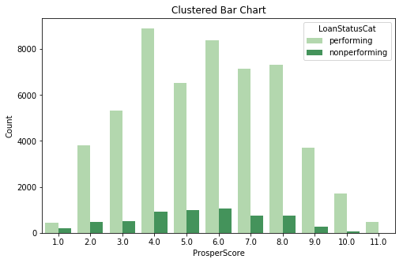

```python
# Clustered Bar Chart
plt.figure(figsize=[8, 5])
sb.countplot(data = df_clean, x = 'ProsperScore', hue = 'LoanStatusCat', palette = 'Greens')

plt.xlabel('ProsperScore')
plt.title('Clustered Bar Chart')
plt.ylabel('Count')
plt.show();
```

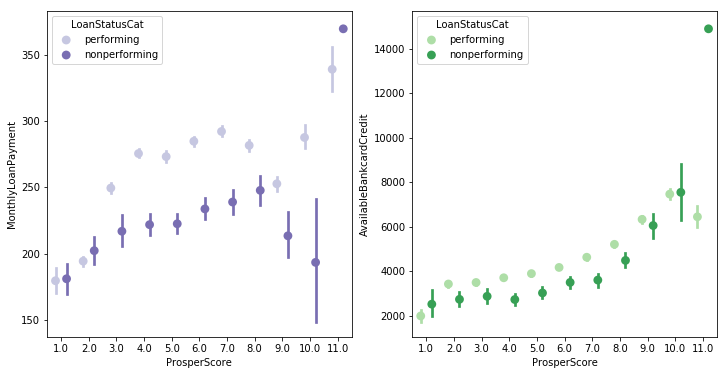

```python
fig, ax = plt.subplots(ncols=2, figsize=[12,6])
sb.pointplot(data = df_clean, x = 'ProsperScore', y = 'MonthlyLoanPayment', hue = 'LoanStatusCat',
           palette = 'Purples', linestyles = '', dodge = 0.4, ax=ax[0])
sb.pointplot(data = df_clean, x = 'ProsperScore', y = 'AvailableBankcardCredit', hue = 'LoanStatusCat',
           palette = 'Greens', linestyles = '', dodge = 0.4, ax=ax[1]);
```